# Final Report Milestone #6

Group 22: Jaemie Anne Abad, Vig Karthik, Kathy LeBert

2023-12-10

## Introduction

To create better county-level health measures to decrease acute asthma cases, an analysis of the California Health and Human Service (CHHS) Department data (2020) for asthma emergency department visits based on various demographic and geographic measures alongside the CalEnviroScreen (CES) 4.0 scores (2021) was conducted with the assistance of data from the California Census.

## Problem Statement

This specific analysis aims to evaluate the relationship between county asthma emergency department rates and CES scores as well as the relationship between county asthma ED visit rates, ED visit counts, pollution burden, housing burden, and race (i.e. if there are existing racial health disparities observed).

## Methods

To assess the relationship between county asthma emergency department (ED) rates and CES scores, age, and race, the project team used CHHS’ Asthma ED Visit Rates by county and CES’ measures and scores datasets. The asthma dataset was segmented by county while the CES dataset was by census tract, so we averaged a county’s census tracts into one county-level measure for further analysis (**Endnote 1**). Then, we merged all datasets. To compare counties, we calculated a CES weighted average using the individual county CES scores and each county’s population. We then made a table that listed the county CES score and percent of the weighted state score (**Endnote 2**). To ease visualization for all of our tables, we limited the rows to Bay Area counties. There were several Not Available or “NA” values in all three datasets and these were recoded to zeroes.

For the race data, we took the original Asthma ED Visit Rates by County dataset and filtered them into individual datasets, each describing all-ages age-adjusted ED visit rate by race. Since these datasets were in long format, we pivoted them into a wider format and to a single table describing age-adjusted ED visit rates and counts. We also made a histogram using the sum of asthma ED visit numbers by race.

At this point, all datasets were processed into their respective strata of interest and all at the county level. We also included Pollution Burden and Housing Burden as socioeconomic variables from the CES datasets.

### Data Dictionary

| VARIABLE | DESCRIPTION |
| --- | --- |
| 2020 Asthma ED visits, 2019 Census, and environmental burden summary | Data dictionary |
| County | California counties |
| CES 4.0 Score | CalEnviroScreen Score |
| CES_score_quartile_range | CES 4.0 score grouped by quartile range of scores |
| Total Population | 2019 ACS population estimates in census tracts |
| white_prct | percetange of population that identify as white |
| white_pop | estimated raw number of population that identify as white, calculated by multiplying percentage to total population |
| non_white_prcp | percentage of population that identify as non-white or multiple race, calculated by summming percentages of all non-white races and others/multile race from raw demographic results in census tract |
| non_white_pop | estimated raw number of population that identify as non-white or multiple race, calculated by multiplying percentage to total population |
| pop_under_10_prct | percentage of population that is less than 10 years old |
| pop_under_10 | estimated raw number of population that is less than 10 years old, calculated by multiplying percentage to total populaiton |
| pop_over_10_prct | percentage of population that is more than 10 years old, calculated by summing population 10 to 64 years and over 64 years |
| pop_over_10 | estimated raw number of population that is more than 10 years old, calculated by multiplying percentage to total population |
| Pollution Burden | Average of percentiles from the Pollution Burden indicators (with a half weighting for the Environmental Effects indicators) |
| Pollution Burden Score | Pollution Burden variable scaled with a range of 0-10. (Used to calculate CES 4.0 Score) |
| Pollution Burden Pctl | Pollution burden percentile |
| Housing Burden | Percent housing burdened low income households |
| Housing Burden Pctl | Housing burden percentile |
| adult_asthma_ed_visits | number of Emergency Department (ED) visits due to asthma for those over 18 years of age |
| child-asthma_ed_visits | number of ED visits due to asthma for those under 18 years of age |
| age-adjusted_ed_visit_rate | age adjusted ED visit rates due to asthma, rate per 10,000 residents |
| white_asthma_ed_visits | number of ED visits due to asthma for those that identify as white |
| non_white_asthma_ed_visits | number of ED visits due to asthma for those that identify as non-white or multiple race |
| White | White (non-Hispanic) race |
| Black | Black race |
| Hispanic | Hispanic race |
| Asian/PI | Asian/Pacific Islander race |
| AI/AN | American Indian/Alaskan Native race |
| NHPI | Native Hawaiian/Pacific Islander race |
| Multi-race | Multiple races |

### Tables & Charts

#### Table 1A-C: Variables of Interest

California All-Ages Asthma Age-Adjusted ED Visit Rate by Race and County, 2020

| County | White | Black | Hispanic | Asian/Pacific Islander | American Indian/Alaskan Native | Native Hawaiian/Pacific Islander | Multi-race |
| --- | --- | --- | --- | --- | --- | --- | --- |
| ALAMEDA | 13.1 | 89.8 | 23.4 | 11.7 | 0 | 59.8 | 20.7 |
| CONTRA COSTA | 15.0 | 98.7 | 28.9 | 11.8 | 0 | 91.5 | 10.7 |
| MARIN | 8.1 | 46.1 | 17.4 | 0.0 | 0 | 0.0 | 0.0 |
| NAPA | 19.7 | 95.1 | 27.4 | 12.2 | 0 | 0.0 | 0.0 |
| SAN FRANCISCO | 9.4 | 100.0 | 25.0 | 7.1 | 0 | 98.9 | 9.2 |
| SAN MATEO | 9.8 | 33.8 | 20.4 | 9.3 | 0 | 36.6 | 6.4 |
| SANTA CLARA | 11.0 | 56.5 | 22.4 | 7.4 | 0 | 50.3 | 5.0 |
| SOLANO | 32.0 | 99.5 | 33.5 | 25.1 | 0 | 154.3 | 17.7 |
| SONOMA | 16.7 | 63.9 | 20.2 | 14.2 | 0 | 78.1 | 0.0 |

California Adult (18+) vs. Child (0-17) Age-Adjusted ED Visit Rate by County, 2020

| County | Adult Age-Adjusted ED Visit Rate | Child Age-Adjusted ED Visit Rate |
| --- | --- | --- |
| ALAMEDA | 26.4 | 24.1 |
| CONTRA COSTA | 27.7 | 26.8 |
| MARIN | 11.8 | 11.7 |
| NAPA | 23.7 | 19.8 |
| SAN FRANCISCO | 15.4 | 19.8 |
| SAN MATEO | 14.6 | 12.2 |
| SANTA CLARA | 15.7 | 11.1 |
| SOLANO | 42.9 | 38.5 |
| SONOMA | 19.6 | 16.4 |

California CES 4.0 Scores, Pollution Burden Scores, Housing Burden % of Population by County, 2021

| County | CES 4.0 Score | Pollution Burden Score | Housing Burden % |
| --- | --- | --- | --- |
| ALAMEDA | 22.71777 | 4.557207 | 15.75250 |
| CONTRA COSTA | 21.03005 | 4.320851 | 14.65411 |
| MARIN | 9.74749 | 3.748051 | 16.41455 |
| NAPA | 17.50928 | 4.549032 | 13.16750 |
| SAN FRANCISCO | 18.03143 | 4.511215 | 15.62256 |
| SAN MATEO | 16.73203 | 4.408726 | 15.36051 |
| SANTA CLARA | 16.94746 | 4.300909 | 14.79624 |
| SOLANO | 24.25958 | 4.222140 | 15.83437 |
| SONOMA | 14.88064 | 3.907693 | 16.01414 |

#### Chart 1: CES Scores and Asthma ED Visit Rates

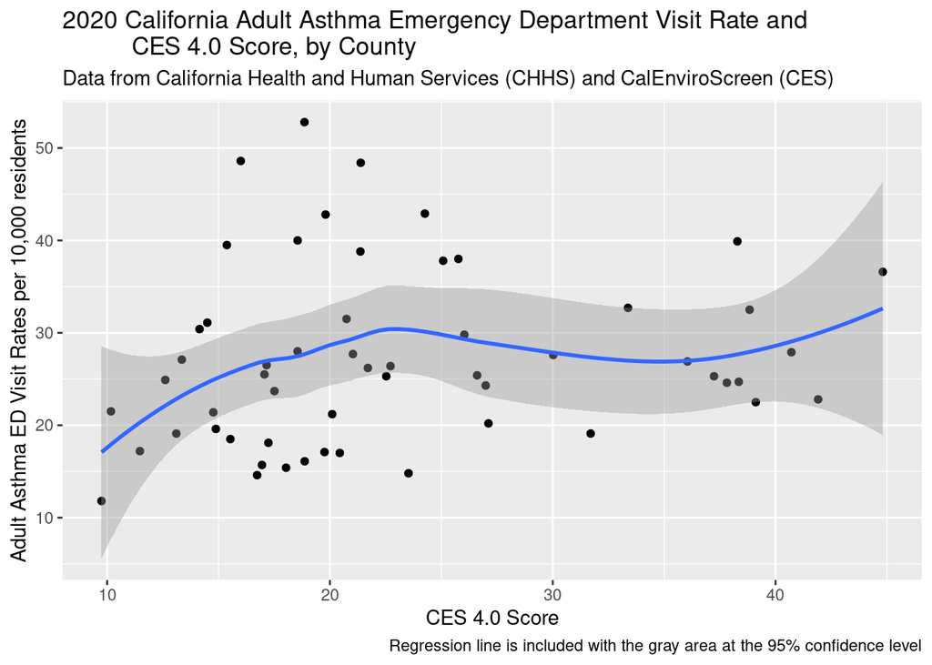

#### Chart 2: Race & Asthma ED Visit Numbers

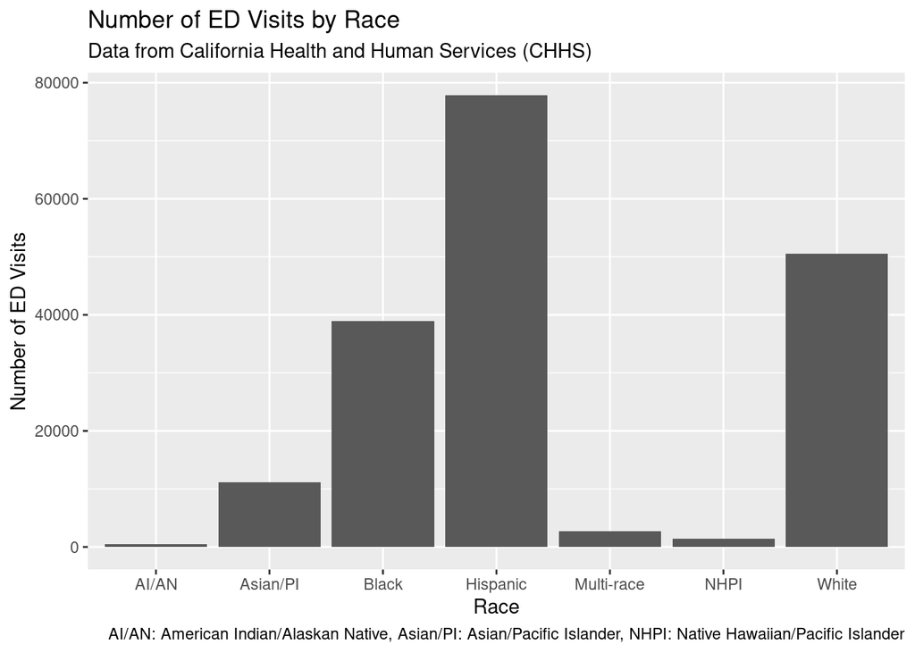

## Results

Three county-level tables were generated using California asthma and CES data. To simplify the discussion, tables (**Tables 1A-C**) focused on the nine Bay Area counties were generated (**Endnote 3**).

In **Table 1C**, assessment for Pollution Burden scores and Housing Burden % as proxies for environmental hazards at the county levels was conducted alongside CES scores. Marin and Sonoma counties had better CES Scores and a lower pollution burden but have a higher percentage of their population housing burdened. Napa had the median CES score but also had the lowest housing burden. Solano has the worst CES score in the Bay Area and is in the upper quartile of housing burden. Alameda and Contra Costa have similar scores across all three metrics.

Putting all three tables together, there appears to be significant variation in age-adjusted asthma ED visit rates across counties and racial categories.

**Chart 1** is a scatterplot of a regression that aims to identify the relationship between CES 4.0 Score and Adult Asthma ED Visit Rates to help identify any patterns between pollution and asthma visits (**Endnote 4**). There appears to be a slight positive relationship between CES score and adult asthma visit rates: counties that are measured to have higher environmental and socioeconomic burdens are associated with increased adult asthma ED visits.

## Discussion

Our analysis of California race and asthma ED visit rates shows that the burden of severe asthma disproportionately falls on Communities of Color, with the rates among Black residents almost 5 times as high as those of White residents. However, as California has a significant proportion of Hispanic residents, the Hispanic category makes up the highest number of ED visits by count. Adult and child asthma ED visit rates are similar within counties (i.e. if one is high then the other is similarly high) but differ compared to other counties. Pollution Burden and Housing Burden varied greatly across counties, with no obvious trends when compared to other variables of interest, but worse CES scores as a whole are associated with more asthma-related visits. Further analysis can be done to determine which other socioeconomic or environmental measures are linked to asthma-impacted communities.

We hope these visualizations will help start discussions of the relationships between asthma and environmental or socioeconomic factors, though gaps in knowledge remain. After further adjustments and research, we hope that our findings can be used to inform asthma-related public health interventions in California and reduce health disparities among age, race, and socioeconomic factors. To make a meaningful impact on the health of Californians with asthma, interventions should be evidence-based and tailored to help the populations (e.g., Communities of Color) experiencing the highest burdens.

## Endnotes

**Endnote 1:** The asthma dataset was segmented by county while the CES dataset was by census tract, so we used the “group” and “summarize” (using the mean) functions to group a county’s census tracts into one county-level measure for further analysis.

**Endnote 2:** Though not included in our main analysis,we made a table named **kable_ces_diff** that listed county CES score and percent of the weighted state score (100%+ meaning worse than the state average and <100% meaning better than the state average).

**Endnote 3:** **Table 1A-C** is meant to be presented as one full table, but has been broken up into three parts for print readability.

**Endnote 4:** A regression line has been included in **Chart 1**, with the gray shaded area depicting the 95% confidence level of the regression model.